# 20220124

Takala

日本秘湯を守る会というものがある．端的に言えば秘湯組合である．

**[日本秘湯を守る会 公式Webサイト](https://www.hitou.or.jp/?=083611)**

現在加盟している秘湯は109箇所．福島県は全国一の15件が加盟している．

本日はそのうちの一軒，奥つちゆ温泉の川上温泉という宿を訪問した． なんと400年以上の歴史があり，現在は十六代目の方が営業に携わってるそう．

[figure not shown]

入口

HPに写真と解説があるが，半分洞窟半分露天の珍しいお風呂が有名：

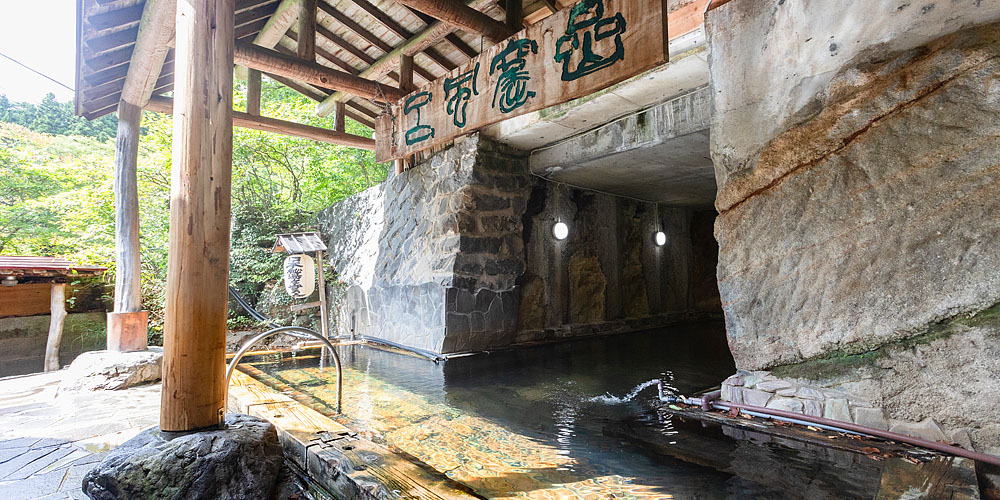

半天嵒窟風呂（公式HPより）

HPにあるこの注意書きは謎である．

> ※2011年3月11日の東日本大震災以降からシャンプー・ボディーソープを設置してあります。 ただし、シャワーはございませんので、浴槽の温泉で洗い流す事になります。 震災を忘れないために設置してあります。

というかHPをあさっていて気づいたが，HPめちゃくちゃ気合入っている．

**[温泉のご案内 - 【公式】土湯温泉 奥土湯 秘湯 川上温泉](http://oko.jp/onsen.htm)**

よく見るとEnglishと繁体中文もある．すげーな．